# demo for stats club

Miriam Goldman

2023-11-27

## Read in GRM and output from population structure test

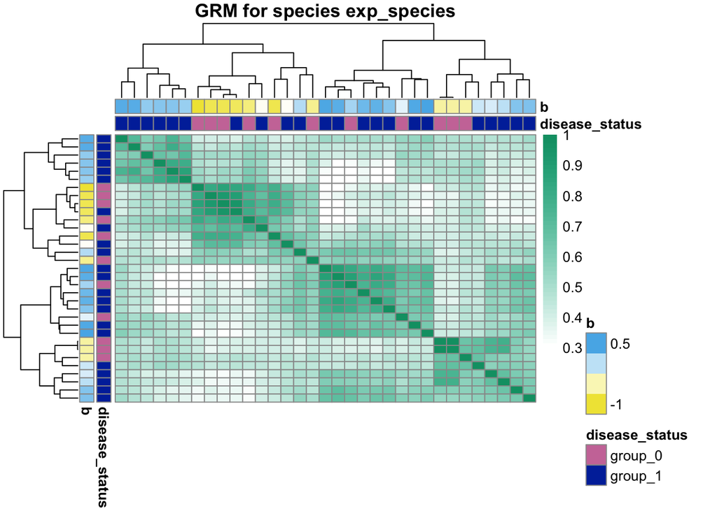

```
## [1] "In the case of this example we have a tau of  2.20788330876276"
```

I have set it up so the most far left cluster was a strain related to the disease while the others were assigned randomly.

This gives us a siginificant tau looking at our write up output.

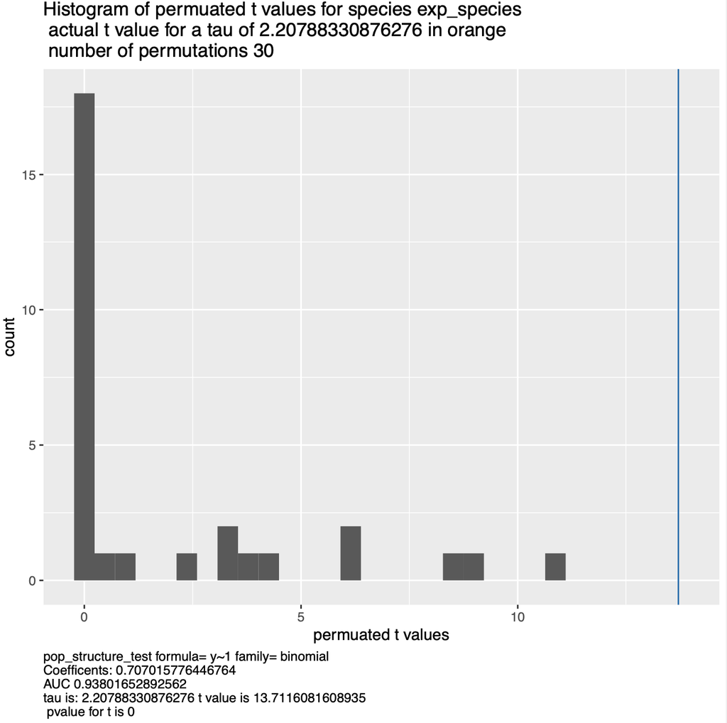

This means we found that the population is significant which it is! So we will move on to the CNV test.

Here the CNV numbers were mostly made modeled on the real data but mostly randomly with the phenotype.

But we are going to mix in 5 genes that move with the structure (modeled from b) and 5 genes mixed in from the phenotype explicitly.

these will be genes 990-999 with 990-994 modeled from b and 995-999 are modeled from the phenotype

example of modeled b copynumber

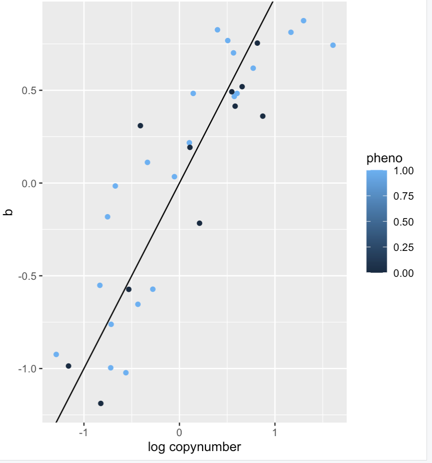

example of modeled pheno

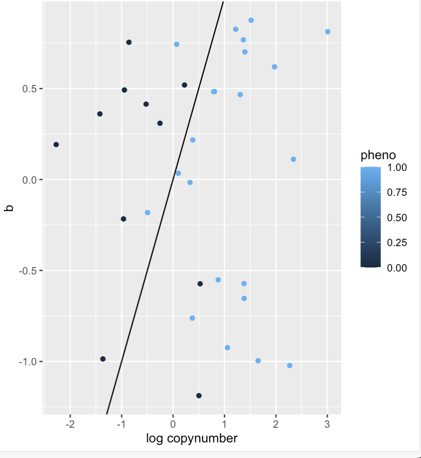

with all of the markers plotted and colored by model

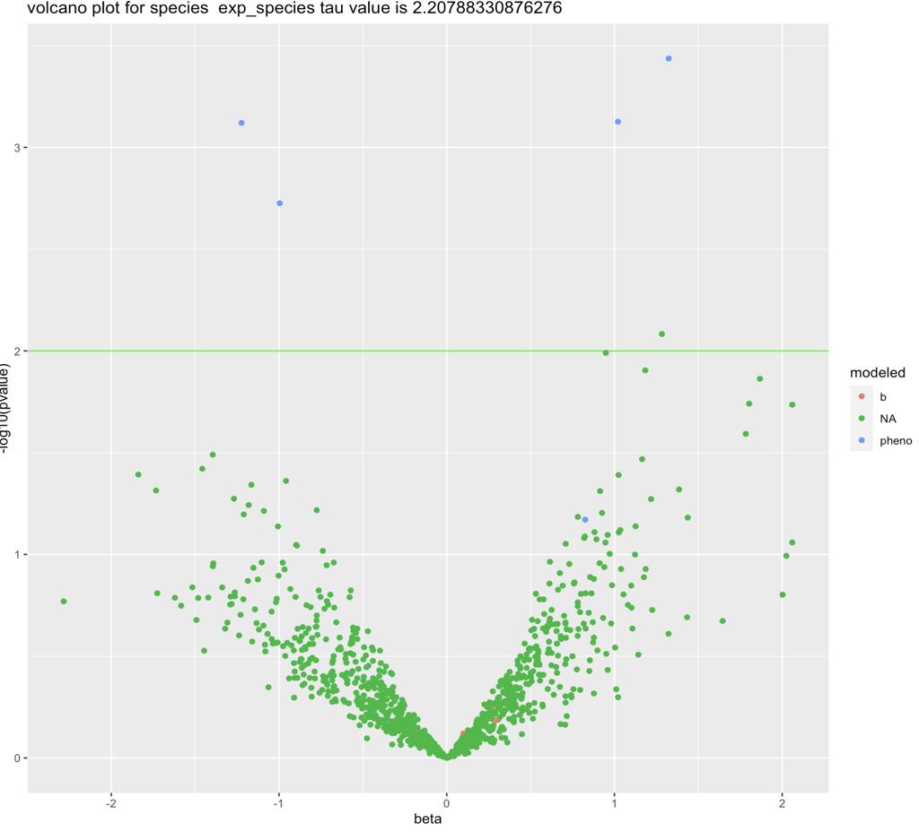

only for those modeled

we can see that those modeled from b are lower than random points this is what we want!

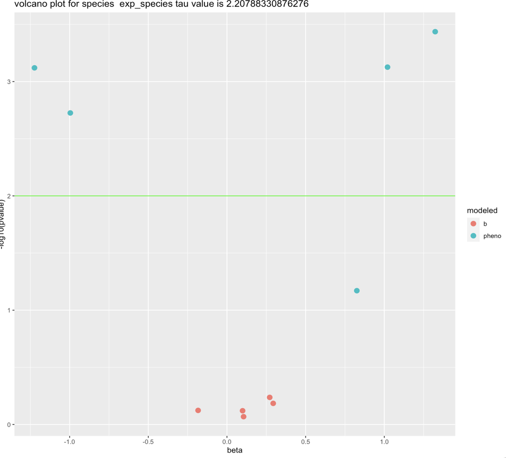